# Bankruptcy Prediction Challenge 💸

## Authors: Yassine Yousfi, Mostafa Bouziane

### (a.k.a. Back-propagated boys)

# 👍

## Model evaluation

```python
def shuffle_split_pimped(clf, X_train, y_train, n):
    ...
    return r
```

- Insures **~20% of positive samples** in test fold
- Insures **~3% of positive samples** in train fold
- Gives **accurate estimates of the leaderboard score** (real life score)
- ~1000 positive samples in the original data set → **limited number of splits** (~7/8)

## Feature engineering

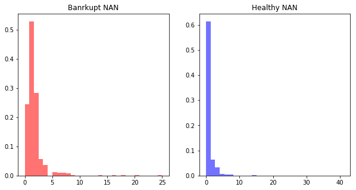

```python
f, (ax1, ax2) = plt.subplots(ncols=2,figsize=(10,5))
ax1.hist(feature_nan[y_train==1], bins = 30, normed=True, facecolor='red', alpha=0.55)
ax1.set_title("Banrkupt NAN")
ax2.hist(feature_nan[y_train==0], bins = 30, normed=True, facecolor='blue', alpha=0.55)
ax2.set_title("Healthy NAN")
plt.show()
```

## Paramaters optimisation

```python
def objective(params):
    params = {
        'max_depth': int(params['max_depth']),
        'gamma': "{:.4f}".format(params['gamma']),
        'colsample_bytree': '{:.4f}'.format(params['colsample_bytree']),
        'scale_pos_weight': int(params['scale_pos_weight']),
        'n_estimators': int(params['n_estimators']),
        'learning_rate': '{:.4f}'.format(params['learning_rate']),
        'subsample': '{:.4f}'.format(params['subsample']),
    }
    clf = XGBClassifier(n_jobs=4, eval_metric="auc", **params)
    score = shuffle_split_pimped(clf, X_train, y_train, 8).mean()
    print("Score {:.4f} params {}".format(score, params))
    return -score

space = {
    'max_depth': hp.quniform('max_depth', 3, 12, 1),
    'colsample_bytree': hp.uniform('colsample_bytree', 0.7, 1.0),
    'gamma': hp.uniform('gamma', 0.0, 0.6),
    'scale_pos_weight': hp.quniform('scale_pose_weight', 10, 100, 1),
    'n_estimators':  hp.quniform('n_estimators', 200, 400, 20),
    'learning_rate':  hp.uniform('learning_rate', 0.04, 0.15),
    'subsample': hp.uniform('subsample', 0.7, 1.0),
}

best = fmin(fn=objective,
            space=space,
            algo=tpe.suggest,
            max_evals=10)
```

[output not shown]

#### Best params:

- **max_depth**: 5
- **gamma**: 0.5819
- **colsample_bytree**: 0.8125
- **scale_pos_weight**: 86
- **n_estimators**: 240
- **learning_rate**: 0.1027
- **subsample**: 0.8511

## Small improvement

Repeat N_rounds time:

- Fit XGBOOST on X_train
- Predict
- Create N_feat random new features based on {+, -, x, ÷} operations and stack them to X_train
- Fit XGBOOST on new X_train
- Compute Feature importances (normed)
- Keep only features with importances > Thresh
- Update X_train

### Why does it work?

Our dataset is composed of ratios, sometimes {+, -, x, ÷} of ratios make sens.

### Draw-back?

Easy overfitting.

# 👎

## SMOTE + ENN

**SMOTE** (Synthetic Minority Over-Sampling Technique)

For each point p in the minority class S:

- Compute its k nearest neighbors in S
- Randomly choose r ≤ k of the neighbors (with re-placement)
- Choose a random point along the lines joining p and each of the r selected neighbors
- Add these synthetic points to the dataset with class S

**ENN** (Edited Nearest Neighbor)

- Remove any example whose class label differs from the class of at least two of its three nearest neighbors

## Draw-backs

- Curse of dimensionality (d = 65) neighbors become quite far
- Removing/adding points near the decision boundary

# 🕵️

## Potential improvements

- Investigate folds where XGBOOST didn't score good and maybe try to fit another classifier
- Further investigate the method with the new random features (tune N_rounds, N_new, thresh, etc.)
- Feature selection > SMOTE